# Course Project - Technical Report and Appendices

Sai Lohith Chimbili (sc2975) & Sahil Parab (sp2627)

2025-05-09

## The project contains the following directories and key files:

#### data/ -

cleaned_dataset_master.csv  
cleaned_dataset_sahil.csv  
cleaned_dataset_lohith.csv  
cleaned_dataset_genre_perROW.csv  
cleaned_dataset_director_perROW.csv  
cleaned_dataset_cast_perROW.csv

#### functions/ -

data_cleaning_lohith.R  
data_cleaning_sahil.R  
data_transformations.R

#### results/ -

Group5_sp2627_sc2975_Project_Technical_Report.Rmd  
Group5_sp2627_sc2975_Project_Technical_Report.html  
Group5_sp2627_sc2975_Project_Business_Report.pdf

## Loading necessary libraries

```r
# Load required libraries
library(tidyverse)
library(rvest)
library(stringr)
library(httr)
library(jsonlite)
```

Appendix A : Data Wrangling, Cleaning and Integration

## Appendix A.1 - Data Web Scrapping from Flickchart

### Appendix A.1.1 - Web Scrapping for ‘title’ metadata column

```r
# Define function to scrape one page of Title
scrape_flickchart_page <- function(page_num) {
  url <- paste0("https://www.flickchart.com/charts.aspx?perpage=10000&page=", page_num)
  #message("Scraping page: ", page_num)

  page <- read_html(url)

  titles <- page %>%
    html_elements("#chart a span") %>%
    html_text(trim = TRUE) %>%
    .[!str_detect(., "http[s]?://")] %>%  # Remove any link-like text
    .[. != ""]                            # Remove empty strings

  tibble(title = titles, page = page_num)
}

# Scrape pages 1 to 40
all_titles <- map_dfr(1:40, scrape_flickchart_page)
nrow(all_titles)
```

```
## [1] 10000
```

```r
all_titles %>% head(10) %>% print()
```

```
## # A tibble: 10 × 2
##    title                     page
##    <chr>                    <int>
##  1 Star Wars                    1
##  2 The Empire Strikes Back      1
##  3 The Godfather                1
##  4 Raiders of the Lost Ark      1
##  5 The Shawshank Redemption     1
##  6 Pulp Fiction                 1
##  7 Return of the Jedi           1
##  8 Back to the Future           1
##  9 Harakiri                     1
## 10 Ikiru                        1
```

### Appendix A.1.2 - Web Scrapping for ‘year’ metadata column

```r
# Define function to scrape one page of Year
scrape_flickchart_page <- function(page_num) {
  url <- paste0("https://www.flickchart.com/charts.aspx?perpage=10000&page=", page_num)
  #message("Scraping page: ", page_num)

  page <- read_html(url)

  titles <- page %>%
    html_elements(".chartsYear") %>%
    html_text(trim = TRUE) %>%
    .[!str_detect(., "http[s]?://")] %>%  # Remove any link-like text
    .[. != ""]                            # Remove empty strings

  tibble(year = titles, page = page_num)
}

# Scrape pages 1 to 40
all_years <- map_dfr(1:40, scrape_flickchart_page)
nrow(all_years)
```

```
## [1] 10000
```

```r
all_years %>% head(10) %>% print()
```

```
## # A tibble: 10 × 2
##    year   page
##    <chr> <int>
##  1 1977      1
##  2 1980      1
##  3 1972      1
##  4 1981      1
##  5 1994      1
##  6 1994      1
##  7 1983      1
##  8 1985      1
##  9 1962      1
## 10 1952      1
```

### Appendix A.1.3 - Web Scrapping for ‘duration’ metadata column

```r
# Define function to scrape one page of Duration in min
scrape_flickchart_page <- function(page_num) {
  url <- paste0("https://www.flickchart.com/charts.aspx?perpage=10000&page=", page_num)
  #message("Scraping page: ", page_num)

  page <- read_html(url)

  titles <- page %>%
    html_elements(".minutes") %>%
    html_text(trim = TRUE) %>%
    .[!str_detect(., "http[s]?://")] %>%  # Remove any link-like text
    .[. != ""]                            # Remove empty strings

  tibble(duration = titles, page = page_num)
}

# Scrape pages 1 to 40
all_duration <- map_dfr(1:40, scrape_flickchart_page)
nrow(all_duration)
```

```
## [1] 10000
```

```r
all_duration %>% head(10) %>% print()
```

```
## # A tibble: 10 × 2
##    duration    page
##    <chr>      <int>
##  1 , 121 min.     1
##  2 , 127 min.     1
##  3 , 175 min.     1
##  4 , 115 min.     1
##  5 , 142 min.     1
##  6 , 154 min.     1
##  7 , 134 min.     1
##  8 , 116 min.     1
##  9 , 133 min.     1
## 10 , 143 min.     1
```

### Appendix A.1.4 - Web Scrapping for ‘director’ metadata column

```r
# Define function to scrape one page of Director name
scrape_flickchart_page <- function(page_num) {
  url <- paste0("https://www.flickchart.com/charts.aspx?perpage=10000&page=", page_num)
  #message("Scraping page: ", page_num)

  page <- read_html(url)

  titles <- page %>%
    html_elements(".director .filterLink:nth-child(1)") %>%
    html_text(trim = TRUE) %>%
    .[!str_detect(., "http[s]?://")] %>%  # Remove any link-like text
    .[. != ""]                            # Remove empty strings

  tibble(director = titles, page = page_num)
}

# Scrape pages 1 to 40
all_director <- map_dfr(1:40, scrape_flickchart_page)
nrow(all_director)
```

```
## [1] 10000
```

```r
all_director %>% head(10) %>% print()
```

```
## # A tibble: 10 × 2
##    director              page
##    <chr>                <int>
##  1 George Lucas             1
##  2 Irvin Kershner           1
##  3 Francis Ford Coppola     1
##  4 Steven Spielberg         1
##  5 Frank Darabont           1
##  6 Quentin Tarantino        1
##  7 Richard Marquand         1
##  8 Robert Zemeckis          1
##  9 Masaki Kobayashi         1
## 10 Akira Kurosawa           1
```

### Appendix A.1.5 - Web Scrapping for ‘genre’ metadata column

```r
# Define function to scrape one page of Genre
scrape_flickchart_page <- function(page_num) {
  url <- paste0("https://www.flickchart.com/charts.aspx?perpage=10000&page=", page_num)
  message("Scraping page: ", page_num)

  page <- read_html(url)

  titles <- page %>%
    html_elements(".genre") %>%
    html_text(trim = TRUE) %>%
    .[!str_detect(., "http[s]?://")] %>%  # Remove any link-like text
    .[. != ""]                            # Remove empty strings

  tibble(genre = titles, page = page_num)
}

# Scrape pages 1 to 40
all_genre <- map_dfr(1:40, scrape_flickchart_page)
nrow(all_genre)
```

```
## [1] 9999
```

### Appendix A.1.6 - Fixing ‘genre’ missing metadata

```r
# ----------------------------
# Diagnose issue: Check how many genres per page
# ----------------------------
df <- all_genre %>%
  group_by(page) %>%
  summarise(count = n())

# ----------------------------
# Fix issue: Page 30 has a missing genre at position 75
# We'll manually insert "Comedy • Comedy Drama" there
# and shift subsequent rows down by one position
# ----------------------------

# Take rows 1 to 74 as-is
all_genre_1 <- all_genre %>% slice(1:74)

# Manually add the missing 75th genre
all_genre_2 <- data.frame(genre = "Comedy • Comedy Drama", page = 30)

# Take the remaining rows from 75 onwards
all_genre_3 <- all_genre %>% slice(75:9999)

# Combine all into final corrected dataset
all_genre_final <- bind_rows(all_genre_1, all_genre_2, all_genre_3)
nrow(all_genre_final)
```

```
## [1] 10000
```

```r
all_genre_final %>% head(10) %>% print()
```

```
## # A tibble: 10 × 2
##    genre                                                                 page
##    <chr>                                                                <dbl>
##  1 Action  •  Adventure  •  Cyborg / Android / Robot                        1
##  2 Action  •  Adventure  •  Cyborg / Android / Robot                        1
##  3 Based-on-20th-Century-Literature  •  Crime Drama  •  Crime               1
##  4 Action  •  Adventure  •  Costume Adventure                               1
##  5 Based-on-20th-Century-Literature  •  Buddy Film  •  Drama                1
##  6 Black Comedy  •  Comedy Thriller  •  Crime Comedy                        1
##  7 Action  •  Adventure  •  Cyborg / Android / Robot                        1
##  8 Adventure Comedy  •  Adventure  •  Americana                             1
##  9 Based-on-20th-Century-Literature  •  Drama  •  Foreign Language Film     1
## 10 Based-on-19th-Century-Literature  •  Drama  •  Foreign Language Film     1
```

### Appendix A.1.7 - Web Scrapping for ‘cast’ metadata column

```r
# Define function to scrape one page of Cast names
scrape_flickchart_page <- function(page_num) {
     url <- paste0("https://www.flickchart.com/charts.aspx?perpage=10000&page=", page_num)
     message("Scraping page: ", page_num)

     page <- read_html(url)

     titles <- page %>%
         html_elements(".director") %>%
         html_text(trim = TRUE) %>%
         .[!str_detect(., "http[s]?://")] %>%  # Remove any link-like text
         .[. != ""]                            # Remove empty strings

     tibble(cast = titles, page = page_num)
}

# Scrape pages 1 to 40
all_cast <- map_dfr(1:40, scrape_flickchart_page)
nrow(all_cast)
```

```
## [1] 10000
```

```r
all_cast %>% head(10) %>% print()
```

```
## # A tibble: 10 × 2
##    cast                                                                     page
##    <chr>                                                                   <int>
##  1 "George Lucas\r\n\t\t\t\t\t\t\t\t\t                                   …     1
##  2 "Irvin Kershner\r\n\t\t\t\t\t\t\t\t\t                                 …     1
##  3 "Francis Ford Coppola\r\n\t\t\t\t\t\t\t\t\t                           …     1
##  4 "Steven Spielberg\r\n\t\t\t\t\t\t\t\t\t                               …     1
##  5 "Frank Darabont\r\n\t\t\t\t\t\t\t\t\t                                 …     1
##  6 "Quentin Tarantino\r\n\t\t\t\t\t\t\t\t\t                              …     1
##  7 "Richard Marquand\r\n\t\t\t\t\t\t\t\t\t                               …     1
##  8 "Robert Zemeckis\r\n\t\t\t\t\t\t\t\t\t                                …     1
##  9 "Masaki Kobayashi\r\n\t\t\t\t\t\t\t\t\t                               …     1
## 10 "Akira Kurosawa\r\n\t\t\t\t\t\t\t\t\t                                 …     1
```

### Appendix A.1.8 - Cleaning ‘cast’ metadata column

```r
# ----------------------------
# Step 1: Clean up the raw 'title' text from all_cast
# ----------------------------
all_cast_clean <- all_cast %>%
  mutate(
    # Remove unwanted control characters: carriage returns (\r), new lines (\n), tabs (\t)
    cast = str_replace_all(cast, "[\r\n\t]", ""),

    # Remove extra white spaces from start, end, and collapse multiple spaces in between
    cast = str_squish(cast)
  )

# ----------------------------
# Step 2: Extract only the cast part from the cleaned titles
# ----------------------------
all_cast_clean1 <- all_cast_clean %>%
  mutate(
    # Extract everything that comes after the phrase "Starring: "
    cast = str_extract(cast, "(?<=Starring: ).*")
  )
nrow(all_cast_clean1)
```

```
## [1] 10000
```

```r
all_cast_clean1 %>% head(10) %>% print()
```

```
## # A tibble: 10 × 2
##    cast                                             page
##    <chr>                                           <int>
##  1 Mark Hamill, Harrison Ford, Carrie Fisher           1
##  2 Mark Hamill, Harrison Ford, Carrie Fisher           1
##  3 Marlon Brando, Al Pacino, James Caan                1
##  4 Harrison Ford, Paul Freeman, Karen Allen            1
##  5 Tim Robbins, Morgan Freeman, Bob Gunton             1
##  6 John Travolta, Samuel L. Jackson, Bruce Willis      1
##  7 Mark Hamill, Harrison Ford, Carrie Fisher           1
##  8 Michael J. Fox, Christopher Lloyd, Lea Thompson     1
##  9 Tatsuya Nakadai, Rentaro Mikuni, Shima Iwashita     1
## 10 Takashi Shimura, Shin'ichi Himori, Haruo Tanaka     1
```

### Appendix A.1.9 - Combining all metadata columns, cleaning the duration to make it numeric and obtain clean dataset

```r
# Select and rename relevant columns from each dataset
cast <- all_cast_clean1 %>% select(cast)
director <- all_director %>% select(director)
duration <- all_duration %>% select(duration)
genre <- all_genre_final %>% select(genre)
year <- all_years %>% select(year)
title <- all_titles %>% select(title)

# Combine all components into a single dataset
movie_data <- bind_cols(title, year, director, duration, cast, genre)

# Step 3: Clean the 'duration' column to make it numeric-ready
movie_data <- movie_data %>%
  mutate(
    duration = str_replace_all(duration, ",", ""),          # Remove commas
    duration = str_remove(duration, "\\s*min\\.?$"),        # Remove "min." or "min" at end (with optional space)
    duration = str_squish(duration),                        # Squash any extra spaces
    duration = as.numeric(duration)                         # Convert to numeric
  )

movie_data |> head(10) |> print()
```

```
## # A tibble: 10 × 6
##    title                    year  director             duration cast       genre
##    <chr>                    <chr> <chr>                   <dbl> <chr>      <chr>
##  1 Star Wars                1977  George Lucas              121 Mark Hami… Acti…
##  2 The Empire Strikes Back  1980  Irvin Kershner            127 Mark Hami… Acti…
##  3 The Godfather            1972  Francis Ford Coppola      175 Marlon Br… Base…
##  4 Raiders of the Lost Ark  1981  Steven Spielberg          115 Harrison … Acti…
##  5 The Shawshank Redemption 1994  Frank Darabont            142 Tim Robbi… Base…
##  6 Pulp Fiction             1994  Quentin Tarantino         154 John Trav… Blac…
##  7 Return of the Jedi       1983  Richard Marquand          134 Mark Hami… Acti…
##  8 Back to the Future       1985  Robert Zemeckis           116 Michael J… Adve…
##  9 Harakiri                 1962  Masaki Kobayashi          133 Tatsuya N… Base…
## 10 Ikiru                    1952  Akira Kurosawa            143 Takashi S… Base…
```

```r
# Save this cleaned dataset to CSV
#write_csv(movie_data, "cleaned_dataset_lohith.csv")
```

## Appendix A.2 - API calls and Data fetching from OMDBAPI for Integration

### Appendix A.2.1 - Fetch movies between 1950 to 2024 for further processing

```r
#Filtering to consider only movies from year 1950 to 2024
data = movie_data |> filter(year >= 1950 & year <= 2024) |> arrange(year)
nrow(data)
```

```
## [1] 8489
```

### Appendix A.2.2 - API Calls to fetch the ratings from OMDBAPI (Warning: Total run time for calls exceeds 30mins)

```r
# API key
api_key = "3b100719"

#Function definition to fetch IMDB ratings from OMDBAPI database using API key
get_rating = function(title, year) {
  title = str_squish(title)
  year = as.integer(year)

  tryCatch(
  {
    # First try with year
    url1 = paste0("http://www.omdbapi.com/?t=",
                   URLencode(title), "&y=", year, "&apikey=", api_key)
    res1 = httr::GET(url1)
    content1 = fromJSON(content(res1, as = "text"))

    if (!is.null(content1$imdbRating) && content1$imdbRating != "N/A")
    {
      return(as.numeric(content1$imdbRating))
    }

    # Fallback: try without year
    url2 = paste0("http://www.omdbapi.com/?t=", URLencode(title), "&apikey=", api_key)
    res2 = httr::GET(url2)
    content2 = fromJSON(content(res2, as = "text"))

    if (!is.null(content2$imdbRating) && content2$imdbRating != "N/A")
    {
      return(as.numeric(content2$imdbRating))
    }
    return(NA)
  },
  error = function(e)
  {
    return(NA)
  })
}

#Fetching the IMDB ratings using funtion call
movies_with_ratings = data |>
  rowwise() |>
  mutate(imdb_rating = get_rating(title, year)) |>
  ungroup()

#Check for a fetched ratings
movies_with_ratings |> select(title, imdb_rating) |> head(10) |> print()
```

```
## # A tibble: 10 × 2
##    title              imdb_rating
##    <chr>                    <dbl>
##  1 Rashômon                   8.2
##  2 Sunset Blvd.               5.2
##  3 In a Lonely Place          7.9
##  4 All About Eve              8.2
##  5 Harvey                     7.9
##  6 The Asphalt Jungle         7.8
##  7 Winchester '73             7.6
##  8 Night and the City         7.8
##  9 Gun Crazy                  7.6
## 10 Los olvidados              6
```

```r
movies_with_ratings |> nrow()
```

```
## [1] 8489
```

### Appendix A.2.3 - Attempt to get missing ratings by simplifying the title

```r
#Checking for NA ratings fetched
na_ratings = movies_with_ratings |> filter(is.na(imdb_rating))

#Remove colon and everything after it for the movies which we coudn't fetch ratings
na_ratings = na_ratings |>
  mutate(title2 = str_trim(str_remove(title, ":.*$")))

#Trying to fetch IMDB ratings again for the one we couldn't do so previously
movies_with_ratings_1 = na_ratings |>
  rowwise() |>
  mutate(imdb_rating = get_rating(title2, year)) |>
  ungroup()

movies_with_ratings_1 |> nrow()
```

```
## [1] 261
```

```r
#Again checking for NA rating fetched
na_ratings2 = movies_with_ratings_1 |> filter(is.na(imdb_rating)) |> print()
```

```
## # A tibble: 184 × 8
##    title                  year  director duration cast  genre imdb_rating title2
##    <chr>                  <chr> <chr>       <dbl> <chr> <chr>       <dbl> <chr>
##  1 Les Enfants Terribles  1950  Jean-Pi…      105 Roge… Horr…          NA Les E…
##  2 A Song of Love         1950  Jean Ge…       26 Java… Avan…          NA A Son…
##  3 Abbott and Costello M… 1951  Charles…       82 Bud … Dram…          NA Abbot…
##  4 Captain Horatio Hornb… 1951  Raoul W…      117 Greg… Acti…          NA Capta…
##  5 Europa '51             1952  Roberto…      113 Ingr… Come…          NA Europ…
##  6 Mr. Hulot's Holiday    1953  Jacques…      114 Jacq… Come…          NA Mr. H…
##  7 Duck Dodgers in the 2… 1953  Chuck J…        7 Mel … Amer…          NA Duck …
##  8 Twelve Angry Men       1954  Frankli…       60 Robe… Acti…          NA Twelv…
##  9 Samurai 1: Musashi Mi… 1954  Hiroshi…       93 Tosh… Come…          NA Samur…
## 10 The Tale of the Cruci… 1954  Kenji M…      102 Kazu… Come…          NA The T…
## # ℹ 174 more rows
```

```r
na_ratings2 |> nrow()
```

```
## [1] 184
```

### Appendix A.2.4 - Merge both the rating tables and remove movies with NA ratings to obtain final cleaned dataset.

```r
# Left join to bring in updated ratings
merged = movies_with_ratings |>
  left_join(movies_with_ratings_1, by = "title", suffix = c("", "_new")) |>
  mutate(imdb_rating = coalesce(imdb_rating, imdb_rating_new)) |>
  select(-imdb_rating_new)

#Removing the extra not required columns
movie_data_rating = merged |>
  select(-which(str_detect(names(merged), "_new")),-title2)

#Remove all the NA value rows and complete the cleaning
movie_data_rating_NoNa = na.omit(movie_data_rating)

movie_data_rating_NoNa |> head(10) |> print()
```

```
## # A tibble: 10 × 7
##    title              year  director            duration cast  genre imdb_rating
##    <chr>              <chr> <chr>                  <dbl> <chr> <chr>       <dbl>
##  1 Rashômon           1950  Akira Kurosawa            88 Tosh… Base…         8.2
##  2 Sunset Blvd.       1950  Billy Wilder             110 Will… Film…         5.2
##  3 In a Lonely Place  1950  Nicholas Ray              94 Hump… Blac…         7.9
##  4 All About Eve      1950  Joseph L. Mankiewi…      138 Bett… Dram…         8.2
##  5 Harvey             1950  Henry Koster             104 Jame… Base…         7.9
##  6 The Asphalt Jungle 1950  John Huston              112 Loui… Comi…         7.8
##  7 Winchester '73     1950  Anthony Mann              92 Dan … Acti…         7.6
##  8 Night and the City 1950  Jules Dassin              96 Rich… Base…         7.8
##  9 Gun Crazy          1950  Joseph H. Lewis           86 Pegg… Anim…         7.6
## 10 Los olvidados      1950  Luis Buñuel               85 Este… Base…         6
```

```r
#Write the cleaned dataset to CSV file
#write_csv(movie_data_rating_NoNa, "cleaned_dataset_sahil.csv")
```

## Appendix A.3 - Bonus Dataset transformations for the cleaned data.

### Appendix A.3.1 - Data Per Director

```r
#Dataset transformation for director per row
final_data_per_dir = movie_data_rating_NoNa |>
  separate_rows(director, sep = ",") |> mutate(director = str_trim(director))

final_data_per_dir |> select(title, director) |> head(10) |> print()
```

```
## # A tibble: 10 × 2
##    title              director
##    <chr>              <chr>
##  1 Rashômon           Akira Kurosawa
##  2 Sunset Blvd.       Billy Wilder
##  3 In a Lonely Place  Nicholas Ray
##  4 All About Eve      Joseph L. Mankiewicz
##  5 Harvey             Henry Koster
##  6 The Asphalt Jungle John Huston
##  7 Winchester '73     Anthony Mann
##  8 Night and the City Jules Dassin
##  9 Gun Crazy          Joseph H. Lewis
## 10 Los olvidados      Luis Buñuel
```

```r
#write_csv(final_data_per_dir, "cleaned_dataset_director_perROW.csv")
```

### Appendix A.3.2 - Data Per Cast

```r
#Dataset transformation for cast per row
final_data_per_cast = movie_data_rating_NoNa |>
  separate_rows(cast, sep = ",") |> mutate(cast = str_trim(cast))

final_data_per_cast |> select(title, cast) |> head(10) |> print()
```

```
## # A tibble: 10 × 2
##    title             cast
##    <chr>             <chr>
##  1 Rashômon          Toshirô Mifune
##  2 Rashômon          Machiko Kyô
##  3 Rashômon          Minoru Chiaki
##  4 Sunset Blvd.      William Holden
##  5 Sunset Blvd.      Gloria Swanson
##  6 Sunset Blvd.      Nancy Olson
##  7 In a Lonely Place Humphrey Bogart
##  8 In a Lonely Place Gloria Grahame
##  9 In a Lonely Place Frank Lovejoy
## 10 All About Eve     Bette Davis
```

```r
#write_csv(final_data_per_cast, "cleaned_dataset_cast_perROW.csv")
```

### Appendix A.3.3 - Data Per Genre

```r
#Dataset transformation for genre per row
final_data_per_genre = movie_data_rating_NoNa |>
  separate_rows(genre, sep = "•") |> mutate(genre = str_trim(genre))

final_data_per_genre |> select(title, genre) |> head(10) |> print()
```

```
## # A tibble: 10 × 2
##    title             genre
##    <chr>             <chr>
##  1 Rashômon          Based-on-20th-Century-Literature
##  2 Rashômon          Crime Drama
##  3 Rashômon          Crime
##  4 Sunset Blvd.      Film Noir
##  5 Sunset Blvd.      Mystery
##  6 Sunset Blvd.      Political Thriller
##  7 In a Lonely Place Black Comedy
##  8 In a Lonely Place Comedy Drama
##  9 In a Lonely Place Drama
## 10 All About Eve     Drama
```

```r
#write_csv(final_data_per_genre, "cleaned_dataset_genre_perROW.csv")
```

### Appendix A.3.4 - Data Per Director, Cast, Genre

```r
#Dataset transformation for atomic values for each cell
final_data_per_dir_per_cast_per_genre = movie_data_rating_NoNa |>
  separate_rows(director, sep = ",") |> mutate(director = str_trim(director)) |>
  separate_rows(cast, sep = ",") |> mutate(cast = str_trim(cast)) |>
  separate_rows(genre, sep = "•") |> mutate(genre = str_trim(genre))

final_data_per_dir_per_cast_per_genre |> select(title, director, cast, genre) |> head(10) |> print()
```

```
## # A tibble: 10 × 4
##    title        director       cast           genre
##    <chr>        <chr>          <chr>          <chr>
##  1 Rashômon     Akira Kurosawa Toshirô Mifune Based-on-20th-Century-Literature
##  2 Rashômon     Akira Kurosawa Toshirô Mifune Crime Drama
##  3 Rashômon     Akira Kurosawa Toshirô Mifune Crime
##  4 Rashômon     Akira Kurosawa Machiko Kyô    Based-on-20th-Century-Literature
##  5 Rashômon     Akira Kurosawa Machiko Kyô    Crime Drama
##  6 Rashômon     Akira Kurosawa Machiko Kyô    Crime
##  7 Rashômon     Akira Kurosawa Minoru Chiaki  Based-on-20th-Century-Literature
##  8 Rashômon     Akira Kurosawa Minoru Chiaki  Crime Drama
##  9 Rashômon     Akira Kurosawa Minoru Chiaki  Crime
## 10 Sunset Blvd. Billy Wilder   William Holden Film Noir
```

```r
#write_csv(final_data_per_dir_per_cast_per_genre, "cleaned_dataset_master.csv")
```

## Appendix A.4 - Final Cleaned Dataset and Insights.

```r
master_data = movie_data_rating_NoNa

# Print first 10 rows of the final dataset
master_data |> head(10) |> print()
```

```
## # A tibble: 10 × 7
##    title              year  director            duration cast  genre imdb_rating
##    <chr>              <chr> <chr>                  <dbl> <chr> <chr>       <dbl>
##  1 Rashômon           1950  Akira Kurosawa            88 Tosh… Base…         8.2
##  2 Sunset Blvd.       1950  Billy Wilder             110 Will… Film…         5.2
##  3 In a Lonely Place  1950  Nicholas Ray              94 Hump… Blac…         7.9
##  4 All About Eve      1950  Joseph L. Mankiewi…      138 Bett… Dram…         8.2
##  5 Harvey             1950  Henry Koster             104 Jame… Base…         7.9
##  6 The Asphalt Jungle 1950  John Huston              112 Loui… Comi…         7.8
##  7 Winchester '73     1950  Anthony Mann              92 Dan … Acti…         7.6
##  8 Night and the City 1950  Jules Dassin              96 Rich… Base…         7.8
##  9 Gun Crazy          1950  Joseph H. Lewis           86 Pegg… Anim…         7.6
## 10 Los olvidados      1950  Luis Buñuel               85 Este… Base…         6
```

The dataset used is a cleaned version of the original and integrated data, with all missing values (NAs) removed.

The dataset contains seven columns. Notably, the ‘cast’, ‘directors’ and ‘genre’ columns can contain multiple values, which should be separated for accurate analysis when examining individual actors or directors.

Appendix B : Data Visualizations and Insights

## Appendix B.1 - Number of Movies per decade Analysis

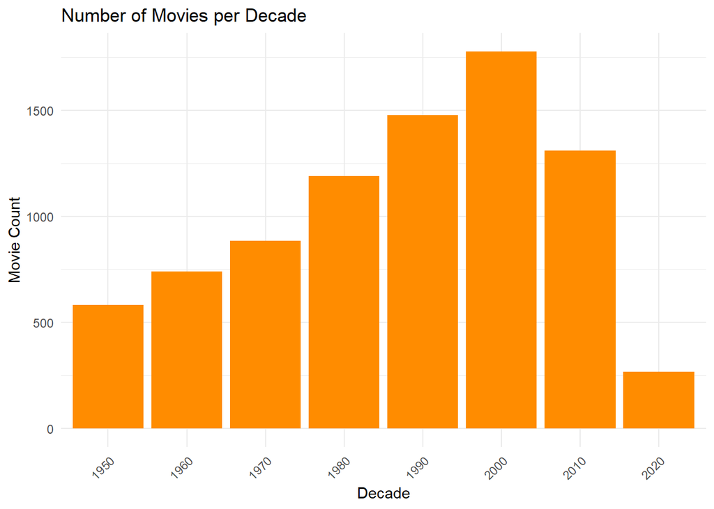

```r
# Create decade column and summarize
a = master_data |>
  mutate(decade = floor(as.numeric(year) / 10) * 10) |>
  group_by(decade) |>
  summarise(total = n(), .groups = "drop")

# Plot the results
ggplot(a, aes(x = as.factor(decade), y = total)) +
  geom_col(fill = "darkorange") +
  labs(
    title = "Number of Movies per Decade",
    x = "Decade",
    y = "Movie Count"
  ) +
  theme_minimal() +
  theme(axis.text.x = element_text(angle = 45, hjust = 1))
```

**Summary:**

The number of movies steadily increased from the 1950s to the 2000s, peaking around 2000, before declining sharply in the 2010s and further in the 2020s. The lower count for the 2020s may be due to the decade still being in progress.

## Appendix B.2 - IMDB ratings per decade Analysis

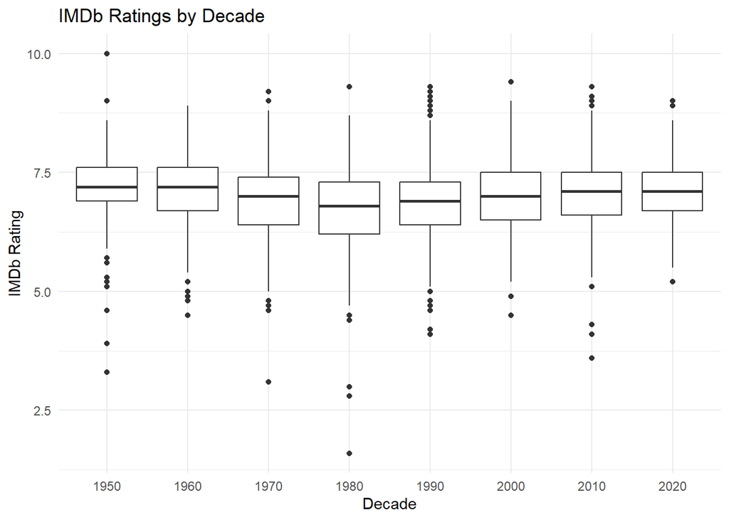

```r
master_data = master_data |>
  mutate(year = as.numeric(year))


decade = master_data |>
  mutate(decade = floor(year / 10) * 10)

ggplot(decade, aes(x = as.factor(decade), y = imdb_rating)) +
  geom_boxplot() +
  scale_x_discrete(name = "Decade") +
  labs(title = "IMDb Ratings by Decade", y = "IMDb Rating") +
  theme_minimal()
```

**Key Observations:**

Notably, movies from the 1980s appear to have received a weaker reception overall, as reflected by the generally lower placement of their boxplot compared to other decades.

**Summary:**

Film ratings have become more varied but stabilized in quality since the mid-20th century. Early cinema is underrepresented and may skew low due to lack of data or retrospective evaluation. The consistent median ratings from the 1950s onward show that audience expectations and critical standards have leveled out, despite increasing film production.

## Appendix B.3 - Top Directors by Average IMDb Rating Analysis

[figure not shown]

```r
top_directors = master_data |>
  group_by(director) |>
  filter(n() >= 5) |>
  summarise(avg_rating = mean(imdb_rating, na.rm = TRUE)) |>
  arrange(desc(avg_rating)) |>
  slice_head(n = 15)

ggplot(top_directors, aes(x = reorder(director, avg_rating), y = avg_rating)) +
  geom_col(fill = "lightblue") +
  coord_flip() +
  labs(title = "Top 15 Directors by Average IMDb Rating (min 5 movies)",
       x = "Director", y = "Average IMDb Rating") + theme_minimal()
```

**Key Observations:**

Masaki Kobayashi leads the list with the highest average IMDb rating — just above 8.0 — suggesting strong consistency and audience acclaim across his works.

Sergio Leone, and Christopher Nolan follow closely, reinforcing their reputation for producing critically acclaimed films with wide audience appeal.

All directors in this list maintain average IMDb ratings above ~7.8, indicating that their filmographies are not just one-hit wonders but consistently well-received.

**Summary:**

A mix of international directors (e.g., Jean-Pierre Melville, Hayao Miyazaki, Tarkovsky) and modern mainstream directors (e.g., Nolan, Villeneuve, Cameron) suggests that excellence in movie directions spans both global cinema and Hollywood.

## Appendix B.4 - Top Genre trends over the decades Analysis

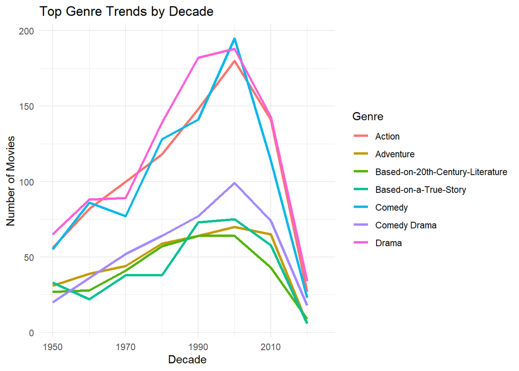

```r
# Extract primary genre and compute decade
genre_decade = master_data |>
  mutate(year = as.numeric(year),
         decade = floor(year / 10) * 10,
         primary_genre = str_trim(str_split_fixed(genre, "•", 2)[, 1])) |>
  filter(!is.na(primary_genre), !is.na(decade))

# Count genres per decade
genre_counts = genre_decade |>
  group_by(decade, primary_genre) |>
  summarise(count = n(), .groups = "drop")

# Plot top genres (filtering top 7 overall for clarity)
top_genres = genre_counts |>
  group_by(primary_genre) |>
  summarise(total = sum(count)) |>
  arrange(desc(total)) |>
  slice_head(n = 7) |>
  pull(primary_genre)

ggplot(genre_counts |>
         filter(primary_genre %in% top_genres),
       aes(x = decade, y = count, color = primary_genre)) +
  geom_line(size = 1.2) +
  scale_x_continuous(breaks = seq(1950, 2020, by = 20), limits = c(1950, 2024)) +
  labs(title = "Top Genre Trends by Decade",
       x = "Decade", y = "Number of Movies", color = "Genre") +
  theme_minimal()
```

**Key Observations:**

1.Drama dominates: Drama has been the most consistently produced genre, especially peaking in the 1990s and 2000s. It shows a steady upward trend from 1960s to 1990s, followed by a sharp decline in the 2020s (likely due to incomplete data or limited releases post-2020).

2.Action & Comedy surged post-1970: Both genres experience explosive growth starting in the 1970s, peaking around the 2000s–2010s. Reflects the rise of blockbusters, franchise films, and global streaming appeal.

3.Based-on-a-True-Story and Adventure grows steadily: Real-life inspired films and Adventure gained popularity in the post-1980s era, likely due to more biopics and historical dramas and rise of enthusiasm for adventure.

4.Based-on-20th-Century-Literature remains steady but modest: Remains a niche genre with stable, lower production volume across decades.

5.Comedy Drama: Comedy had a stable and a visible rise in the 1950s–2000s, indicating a trend toward hybrid emotional storytelling.

6.Sharp drop after 2010: The decline across all genres in the 2020s is likely due to:

i)Fewer releases post-2020 (pandemic impact).

ii)Limited dataset coverage for recent years.

**Summary**

This chart highlights how social tastes, media formats, and production trends have shifted over time. Drama remains the most produced, while Action, Adventure, and true-story adaptations have risen with modern cinema’s commercial and emotional trends.

## Appendix B.5 - Average Movie Runtime by Decade Analysis

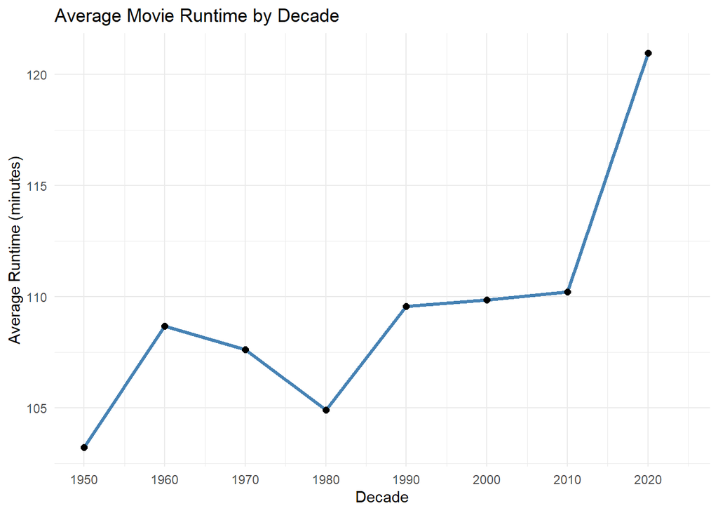

```r
runtime_decade = master_data |>
  mutate(year = as.numeric(year),
         duration = as.numeric(duration),
         decade = floor(year / 10) * 10) |>
  filter(!is.na(duration), duration > 20, duration < 300)  # filtering unrealistic values

runtime_trend = runtime_decade |>
  group_by(decade) |>
  summarise(avg_runtime = mean(duration, na.rm = TRUE), .groups = "drop")

ggplot(runtime_trend, aes(x = decade, y = avg_runtime)) +
  geom_line(color = "steelblue", size = 1.2) +
  geom_point(size = 2) +
  scale_x_continuous(breaks = seq(1950, 2020, by = 10), limits = c(1950, 2024)) +
  labs(title = "Average Movie Runtime by Decade",
       x = "Decade", y = "Average Runtime (minutes)") +
  theme_minimal()
```

**Key Observations:**

1.Stabilization from 1950s–2000s (~100–110 mins): For about 6 decades, average runtime stays relatively stable. Hollywood and global films found an optimal storytelling length here.

2.Modern Increase in the 2020s (~120 mins): Likely be attributed to several factors: streaming platforms enabling longer formats, the rise of superhero franchises, epic dramas, and multi-part stories, as well as reduced theatrical constraints, which offer directors greater creative freedom.

## Appendix B.6 - Average Runtime by Genre and Decade Analysis

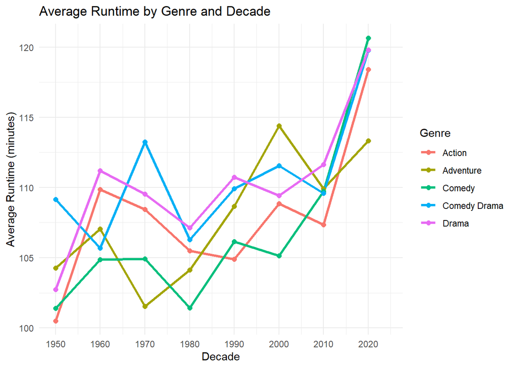

```r
# Prepare data
runtime_by_genre = master_data |>
  mutate(
    year = as.numeric(year),
    duration = as.numeric(duration),
    decade = floor(year / 10) * 10,
    primary_genre = str_trim(str_split_fixed(genre, "•", 2)[, 1])
  ) |>
  filter(!is.na(duration), duration > 20, duration < 300, !is.na(primary_genre), !is.na(decade))

# Focus on top 5 most common genres
top_genres = runtime_by_genre |>
  count(primary_genre, sort = TRUE) |>
  slice_head(n = 5) |>
  pull(primary_genre)

# Compute average runtime per genre per decade
avg_runtime_genre = runtime_by_genre |>
  filter(primary_genre %in% top_genres) |>
  group_by(decade, primary_genre) |>
  summarise(avg_runtime = mean(duration, na.rm = TRUE), .groups = "drop")

# Plot
ggplot(avg_runtime_genre, aes(x = decade, y = avg_runtime, color = primary_genre)) +
  geom_line(size = 1.2) +
  geom_point(size = 2) +
  scale_x_continuous(breaks = seq(1950, 2020, by = 10), limits = c(1950, 2024)) +
  labs(
    title = "Average Runtime by Genre and Decade",
    x = "Decade", y = "Average Runtime (minutes)",
    color = "Genre"
  ) +
  theme_minimal()
```

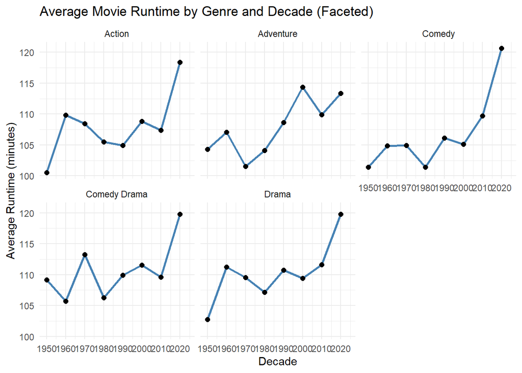

```r
ggplot(avg_runtime_genre, aes(x = decade, y = avg_runtime)) +
  geom_line(color = "steelblue", size = 1) +
  geom_point(color = "black", size = 2) +
  facet_wrap(~ primary_genre) +
  scale_x_continuous(breaks = seq(1950, 2020, by = 10), limits = c(1950, 2024)) +
  labs(
    title = "Average Movie Runtime by Genre and Decade (Faceted)",
    x = "Decade", y = "Average Runtime (minutes)"
  ) +
  theme_minimal()
```

**General Trend:**

**The rise may be due to:**

Streaming platforms enabling more flexible formats.

Increasing viewer tolerance for long-form storytelling.

Bigger budgets, multi-part sagas, and extended cut.

## Appendix B.7 - IMDB Rating vs Average Runtime by Genre Analysis

[figure not shown]

```r
ggplot(runtime_by_genre |>
         filter(primary_genre %in% top_genres),
       aes(x = duration, y = imdb_rating, color = primary_genre)) +
  geom_point(alpha = 0.1) +
  geom_smooth(method = "loess", se = FALSE) +
  labs(
    title = "IMDb Rating vs Runtime by Genre",
    x = "Runtime (minutes)", y = "IMDb Rating", color = "Genre"
  ) +
  theme_minimal()
```

**Key Observations:**

Adventure: Longer Adventure movies tend to receive significantly higher ratings, especially beyond the 150-minute mark. Suggests that audiences reward deeper, expansive storytelling typical of epic adventures.

Comedy: Shorter comedies (<90 mins) tend to get higher ratings. There’s a sudden drop in ratings if movie drags on beyond 90 mins mark which might be because of sturation of humour. A subtle improvement in ratings with increasing length, but still flats around 7.5—implying that comedy success is more about content than length.

Action: Longer Action movies tend to receive significantly higher ratings as the duration increases.

Drama: Fairly stable trend, with moderate increases until ~180 mins. Beyond that, ratings stabilize or dip, possibly reflecting diminishing returns for overly long dramas.

**Summary:**

Longer runtimes tend to correlate with higher ratings for genres like Adventure, Drama, and Comedy Drama. However, extreme runtimes do not necessarily lead to higher ratings and may hurt pacing and engagement.

## Appendix B.8 - Top 15 most frequent Actors Analysis

```r
cast_long = master_data |>
  select(title, year, imdb_rating, cast) |>
  separate_rows(cast, sep = ",\\s*") |>
  mutate(cast = str_squish(cast)) |>
  filter(cast != "")

actor_counts = cast_long |>
  count(cast, sort = TRUE)

actor_ratings = cast_long |>
  group_by(cast) |>
  summarise(
    num_movies = n(),
    avg_rating = mean(imdb_rating, na.rm = TRUE),
    .groups = "drop"
  ) |>
  filter(num_movies >= 5) |>
  arrange(desc(avg_rating))
```

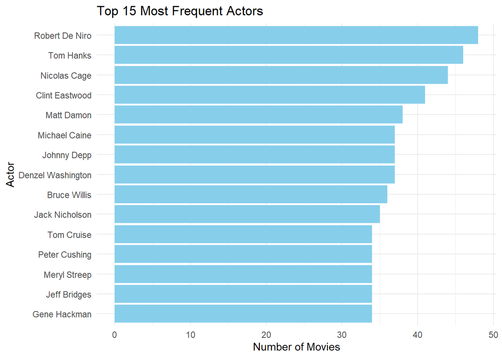

```r
top_actors = actor_counts |> slice_max(n, n = 15)

ggplot(top_actors, aes(x = reorder(cast, n), y = n)) +
  geom_col(fill = "skyblue") +
  coord_flip() +
  labs(title = "Top 15 Most Frequent Actors", x = "Actor", y = "Number of Movies") +
  theme_minimal()
```

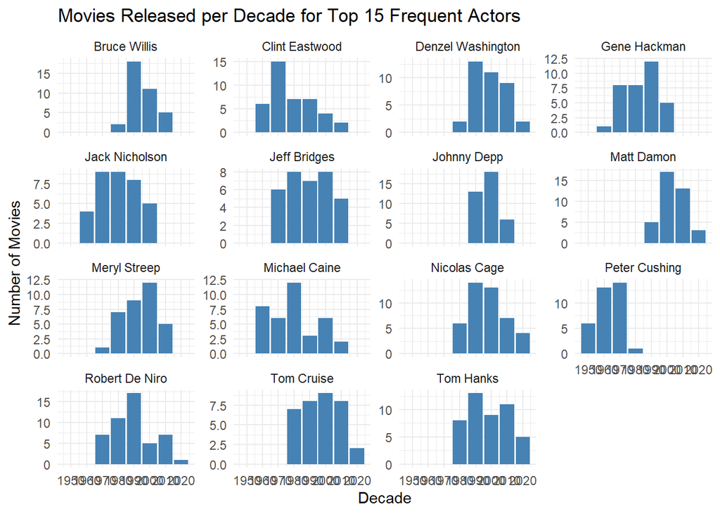

```r
cast_long = cast_long |>
  mutate(year = as.numeric(year)) |>
  filter(!is.na(year))

# Get top 15 most frequent actors
top_actors = cast_long |>
  count(cast, sort = TRUE) |>
  slice_max(n, n = 15) |>
  pull(cast)

# Filter for those actors and calculate decade
actor_decades = cast_long |>
  filter(cast %in% top_actors) |>
  mutate(decade = floor(year / 10) * 10)

# Group and count
actor_decade_counts = actor_decades |>
  group_by(cast, decade) |>
  summarise(movie_count = n(), .groups = "drop")


ggplot(actor_decade_counts, aes(x = decade, y = movie_count)) +
  geom_col(fill = "steelblue") +
  facet_wrap(~ cast, scales = "free_y") +
  scale_x_continuous(breaks = seq(1950, 2020, by = 10)) +
  labs(title = "Movies Released per Decade for Top 15 Frequent Actors",
       x = "Decade", y = "Number of Movies") +
  theme_minimal()
```

**Summary:**

Robert De Niro, Tom Hanks, Nicolas Cage, and Clint Eastwood dominate the charts, each appearing in over 40 movies between the 1950s and 2020s.

Notably, the list is dominated by Hollywood actors—which isn’t surprising given Hollywood’s historically high volume of film production compared to international film industries.

## Appendix B.9 - Top 15 Actors by Avg IMDB Rating Analysis

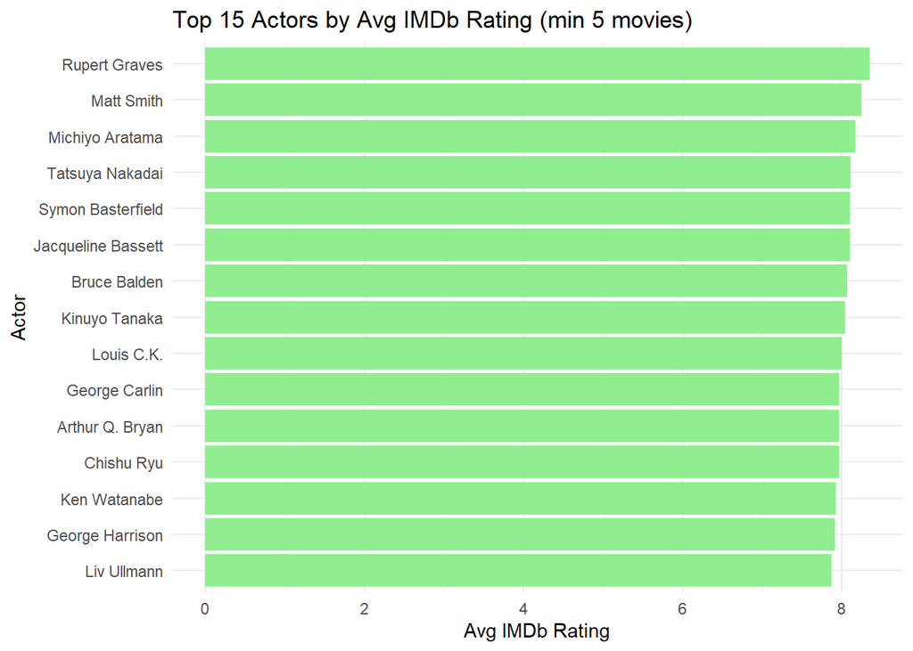

```r
top_rated_actors = actor_ratings |> slice_max(avg_rating, n = 15)

ggplot(top_rated_actors, aes(x = reorder(cast, avg_rating), y = avg_rating)) +
  geom_col(fill = "lightgreen") +
  coord_flip() +
  labs(title = "Top 15 Actors by Avg IMDb Rating (min 5 movies)", x = "Actor", y = "Avg IMDb Rating") +
  theme_minimal()
```

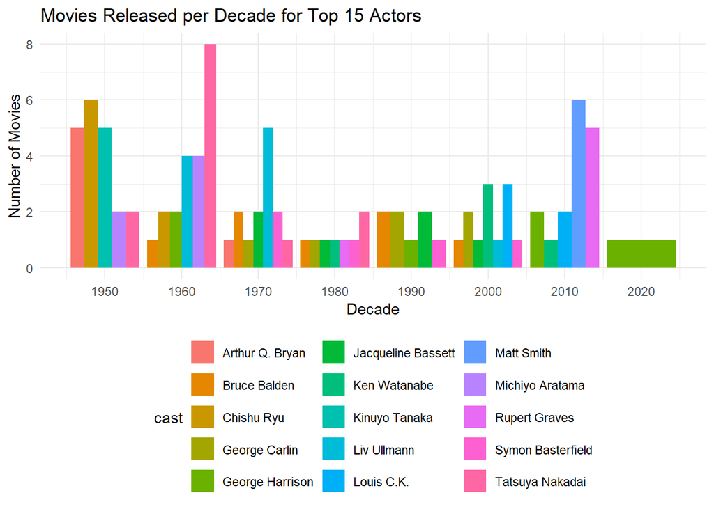

```r
top_actor_names = top_rated_actors$cast

cast_decade = cast_long |>
  filter(cast %in% top_actor_names) |>
  mutate(decade = floor(as.numeric(year) / 10) * 10)
actor_decade_counts <- cast_decade |>
  group_by(cast, decade) |>
  summarise(movie_count = n(), .groups = "drop")


ggplot(actor_decade_counts, aes(x = decade, y = movie_count, fill = cast)) +
  geom_col(position = "dodge") +
  scale_x_continuous(breaks = seq(1950, 2020, by = 10)) +
  labs(title = "Movies Released per Decade for Top 15 Actors",
       x = "Decade", y = "Number of Movies") +
  theme_minimal() +
  theme(legend.position = "bottom") +
  guides(fill = guide_legend(ncol = 3))
```

**Summary:**

An important observation is that when IMDB ratings are used to identify top actors, the charts are largely dominated by actors from international film industries rather than Hollywood.

A possible explanation is that these international actors appeared in fewer films compared to their Hollywood counterparts, and the limited number of roles they took on were rated more highly—resulting in a higher average IMDB rating.